# Mananjary cohort malaria epi analysis

Benny Rice

2022-11-28

# 1 Set up

## 1.1 Header info

- Benjamin Rice on behalf of the Princeton-CRS Research Team
- Processing malaria rapid diagnostic test data and associated data
- Cleaning data and visualizing data collected 2021-2022
- Aim 1: Visualize temporal trends in malaria infection
- Aim 2: Organize data to apply a HMM to better model time course of infection among sampled individuals
- Aim 3: Associate malaria infection outcome data with relevant covariates for plotting

## 1.2 Loading necessary packages

# 2 Playing with S6: Tidying Data

## 2.1 Reading in data

```r
#Playing with S6
df1i <- readxl::read_excel("/Users/blrice/Documents/R GIT REPOS/2022_MNJ_TAZO/data_rdt/S6_DATA_ENTRY_20221126t.xlsx")
head(df1i)
```

```
## # A tibble: 6 × 56
##   uniqu…¹ site_…² hh_id CODE  dob_yr dob_mo dob_day sex   rdt_T8 visit…³ visit…⁴
##   <chr>   <chr>   <chr> <chr> <chr>  <chr>  <chr>   <chr> <chr>  <chr>   <chr>
## 1 S6.01.… S6      S6.01 01.01 1990   1      17      L     pf     18_Oct  2022
## 2 S6.01.… S6      S6.01 01.02 1997   3      15      V     neg    18_Oct  2022
## 3 S6.01.… S6      S6.01 01.03 2012   3      14      V     neg    18_Oct  2022
## 4 S6.01.… S6      S6.01 01.04 2014   7      15      V     neg    18_Oct  2022
## 5 S6.01.… S6      S6.01 01.05 2019   10     22      V     neg    18_Oct  2022
## 6 S6.01.… S6      S6.01 01.06 2022   NA     NA      V     neg    18_Oct  2022
## # … with 45 more variables: visit_T8_mo <chr>, visit_T8_day <chr>,
## #   obs_T8 <chr>, rdt_T7 <chr>, visit_T7 <chr>, visit_T7_yr <chr>,
## #   visit_T7_mo <chr>, visit_T7_day <chr>, obs_T7 <chr>, rdt_T6 <chr>,
## #   visit_T6 <chr>, visit_T6_yr <chr>, visit_T6_mo <chr>, visit_T6_day <chr>,
## #   obs_T6 <chr>, rdt_T5 <chr>, visit_T5 <chr>, visit_T5_yr <chr>,
## #   visit_T5_mo <chr>, visit_T5_day <chr>, obs_T5 <chr>, rdt_T4 <chr>,
## #   visit_T4 <chr>, visit_T4_yr <chr>, visit_T4_mo <chr>, visit_T4_day <chr>, …
```

```r
#Dropping blank rows
df1i <- df1i %>% filter(!(is.na(unique_ind_id)))
str(df1i)
```

```
## tibble [344 × 56] (S3: tbl_df/tbl/data.frame)
##  $ unique_ind_id: chr [1:344] "S6.01.01" "S6.01.02" "S6.01.03" "S6.01.04" ...
##  $ site_code    : chr [1:344] "S6" "S6" "S6" "S6" ...
##  $ hh_id        : chr [1:344] "S6.01" "S6.01" "S6.01" "S6.01" ...
##  $ CODE         : chr [1:344] "01.01" "01.02" "01.03" "01.04" ...
##  $ dob_yr       : chr [1:344] "1990" "1997" "2012" "2014" ...
##  $ dob_mo       : chr [1:344] "1" "3" "3" "7" ...
##  $ dob_day      : chr [1:344] "17" "15" "14" "15" ...
##  $ sex          : chr [1:344] "L" "V" "V" "V" ...
##  $ rdt_T8       : chr [1:344] "pf" "neg" "neg" "neg" ...
##  $ visit_T8     : chr [1:344] "18_Oct" "18_Oct" "18_Oct" "18_Oct" ...
##  $ visit_T8_yr  : chr [1:344] "2022" "2022" "2022" "2022" ...
##  $ visit_T8_mo  : chr [1:344] "10" "10" "10" "10" ...
##  $ visit_T8_day : chr [1:344] "18" "18" "18" "18" ...
##  $ obs_T8       : chr [1:344] "NA" "NA" "NA" "NA" ...
```

[output cut: 42 more lines]

## 2.2 Cleaning up columns

- First, need to rename columns to make easier to use with pivot_longer
- Using only “_” to separate time point from variable

```r
names(df1i) <- c("unique_ind_id", "site_code", "hh_id", "CODE", "dob_yr", "dob_mo", "dob_day", "sex",
                 "rdt_T8", "visit_T8", "yr.visit_T8", "mo.visit_T8", "day.visit_T8", "obs_T8",
                 "rdt_T7", "visit_T7", "yr.visit_T7", "mo.visit_T7", "day.visit_T7", "obs_T7",
                 "rdt_T6", "visit_T6", "yr.visit_T6", "mo.visit_T6", "day.visit_T6", "obs_T6",
                 "rdt_T5", "visit_T5", "yr.visit_T5", "mo.visit_T5", "day.visit_T5", "obs_T5",
                 "rdt_T4", "visit_T4", "yr.visit_T4", "mo.visit_T4", "day.visit_T4", "obs_T4",
                 "rdt_T3", "visit_T3", "yr.visit_T3", "mo.visit_T3", "day.visit_T3", "obs_T3",
                 "rdt_T2", "visit_T2", "yr.visit_T2", "mo.visit_T2", "day.visit_T2", "obs_T2",
                 "rdt_T1", "visit_T1", "yr.visit_T1", "mo.visit_T1", "day.visit_T1", "obs_T1")
```

- Formatting date columns into a sample.date column

```r
#Combining year, month, and date into a formatted sample.date column
df1 <- df1i %>%
  #Converting "NA"s to NAs
  #To avoid doing for all columns one at a time, using across() to apply to a set of columns
  #Using "." to simply pass each column from before into the na_if() function
  mutate(across(dob_yr:obs_T1, ~ na_if(., "NA"))) %>%
  #Adding a combined date column for each time_point using ymd()
  #Probably is a more elegant way to do this
  #Note because individuals not sampled at a time point have NAs, will be some dates that don't parse
  mutate(sample.date_T8 = ymd(paste0(yr.visit_T8, "-", mo.visit_T8, "-", day.visit_T8)),
         sample.date_T7 = ymd(paste0(yr.visit_T7, "-", mo.visit_T7, "-", day.visit_T7)),
         sample.date_T6 = ymd(paste0(yr.visit_T6, "-", mo.visit_T6, "-", day.visit_T6)),
         sample.date_T5 = ymd(paste0(yr.visit_T5, "-", mo.visit_T5, "-", day.visit_T5)),
         sample.date_T4 = ymd(paste0(yr.visit_T4, "-", mo.visit_T4, "-", day.visit_T4)),
         sample.date_T3 = ymd(paste0(yr.visit_T3, "-", mo.visit_T3, "-", day.visit_T3)),
         sample.date_T2 = ymd(paste0(yr.visit_T2, "-", mo.visit_T2, "-", day.visit_T2)),
         sample.date_T1 = ymd(paste0(yr.visit_T1, "-", mo.visit_T1, "-", day.visit_T1)))
#Dropping the unnecessary date columns, CODE columns
df1 <- df1 %>% select("unique_ind_id", "site_code", "hh_id", "dob_yr", "dob_mo", "dob_day", "sex",
                      "rdt_T8", "sample.date_T8", "obs_T8",
                      "rdt_T7", "sample.date_T7", "obs_T7",
                      "rdt_T6", "sample.date_T6", "obs_T6",
                      "rdt_T5", "sample.date_T5", "obs_T5",
                      "rdt_T4", "sample.date_T4", "obs_T4",
                      "rdt_T3", "sample.date_T3", "obs_T3",
                      "rdt_T2", "sample.date_T2", "obs_T2",
                      "rdt_T1", "sample.date_T1", "obs_T1")
```

- Fixing DOBs
- For now:
  - If month unknown, use June
  - If date unknown, use 15th

```r
#Fixing dobs
#Converting to numeric
#If month unknown, use June as a guess for now
#If date unknown, use 15th as a guess for now
df2 <- df1 %>%
  mutate(dob_yr  = as.numeric(dob_yr)) %>%
  mutate(dob_mo  = as.numeric(dob_mo)) %>%
  mutate(dob_mo  = replace_na(dob_mo, 6)) %>%
  mutate(dob_day = as.numeric(dob_day)) %>%
  mutate(dob_day = replace_na(dob_day, 15)) %>%
  #Combining into a dob column, date format
  mutate(dob = ymd(paste0(dob_yr, "-", dob_mo, "-", dob_day))) %>%
  #Selecting columns
  select("unique_ind_id", "site_code", "hh_id", "dob", "sex",
         "rdt_T8", "sample.date_T8", "obs_T8",
         "rdt_T7", "sample.date_T7", "obs_T7",
         "rdt_T6", "sample.date_T6", "obs_T6",
         "rdt_T5", "sample.date_T5", "obs_T5",
         "rdt_T4", "sample.date_T4", "obs_T4",
         "rdt_T3", "sample.date_T3", "obs_T3",
         "rdt_T2", "sample.date_T2", "obs_T2",
         "rdt_T1", "sample.date_T1", "obs_T1")
```

## 2.3 Tidying data: Pivoting longer

- Pivoting longer

```r
#Pivoting longer
df3 <- df2 %>%
  #Undoing date format to allow combining
  mutate(across(rdt_T8:obs_T1, ~ as.character(.))) %>%
  pivot_longer(
    #Specify the columns to tuck under
    #NOT The columns to stay at the left
    cols = !(unique_ind_id:sex),
    #Splitting the variable (e.g., rdt result) from the time point (e.g., T8)
    #Using the spacer "_" that separates variable name from time_point
    names_to = c("variable", "time_point"),
    names_sep = "_",
    #sending values to a column named value
    values_to = "value"
  )
head(df3)
```

```
## # A tibble: 6 × 8
##   unique_ind_id site_code hh_id dob        sex   variable    time_point value
##   <chr>         <chr>     <chr> <date>     <chr> <chr>       <chr>      <chr>
## 1 S6.01.01      S6        S6.01 1990-01-17 L     rdt         T8         pf
## 2 S6.01.01      S6        S6.01 1990-01-17 L     sample.date T8         2022-10…
## 3 S6.01.01      S6        S6.01 1990-01-17 L     obs         T8         <NA>
## 4 S6.01.01      S6        S6.01 1990-01-17 L     rdt         T7         neg
## 5 S6.01.01      S6        S6.01 1990-01-17 L     sample.date T7         2022-08…
## 6 S6.01.01      S6        S6.01 1990-01-17 L     obs         T7         <NA>
```

- Too long: Pivoting wider to get columns for sample.date and observations

```r
#Pivoting wider to get columns for sample.date and observations
df4 <- df3 %>%
  pivot_wider(names_from = variable, values_from = value) %>%
  #converting sample.date back to date format
  mutate(sample.date = ymd(sample.date))
head(df4)
```

```
## # A tibble: 6 × 9
##   unique_ind_id site_code hh_id dob        sex   time_p…¹ rdt   sample.d…² obs
##   <chr>         <chr>     <chr> <date>     <chr> <chr>    <chr> <date>     <chr>
## 1 S6.01.01      S6        S6.01 1990-01-17 L     T8       pf    2022-10-18 <NA>
## 2 S6.01.01      S6        S6.01 1990-01-17 L     T7       neg   2022-08-24 <NA>
## 3 S6.01.01      S6        S6.01 1990-01-17 L     T6       neg   2022-07-07 <NA>
## 4 S6.01.01      S6        S6.01 1990-01-17 L     T5       neg   2022-05-19 <NA>
## 5 S6.01.01      S6        S6.01 1990-01-17 L     T4       neg   2022-03-31 <NA>
## 6 S6.01.01      S6        S6.01 1990-01-17 L     T3       neg   2022-01-11 <NA>
## # … with abbreviated variable names ¹time_point, ²sample.date
```

## 2.4 Recoding RDT results

### 2.4.1 Recoding as

[output not shown]

```r
#Recoding RDT result
table(df4$rdt)
```

```
##
##   inv   neg   pan panpf    pf    pg
##     1  1346    17   107   375     1
```

```r
df5 <- df4 %>% mutate(rdt = case_when(
  rdt == "inv"   ~ NA_real_,
  rdt == "neg"   ~ 0,
  rdt == "pf"    ~ 1,
  rdt == "pan"   ~ 1,
  rdt == "panpf" ~ 1))
table(df5$rdt)
```

```
##
##    0    1
## 1346  499
```

# 3 Playing with S6: First plots

- X-axis: **time_point** or **real dates**;
- Y-axis: unique_ind_id faceted by household;
- Dots colored by infection status:
  - Absent/un-sampled: leave blank
  - Negative: grey
  - Positive: orange

```r
p3_01a.cols <- c("0" = "#8A877B", "1" = "#EB6429")
p3_01a <- df5 %>%
  #Drop rows with no data
  filter(!is.na(rdt)) %>% filter(!is.na(sample.date)) %>%
  #Show X households at a time
  filter(hh_id %in% unique(df5$hh_id)[1:10]) %>%
  ggplot(aes(x = time_point, y = unique_ind_id, color = as.factor(rdt))) +
  geom_point() +
  scale_colour_manual(values = p3_01a.cols) +
  facet_grid(rows = vars(hh_id), scales = "free_y", space = "free") +
  xlab("Time") + ylab("Individuals") +
  labs(color="Infection status") +
  theme_bw() +
  theme(strip.background = element_rect(fill = "white"),
        axis.text.y = element_blank())

p3_01b <- df5 %>%
  #Drop rows with no data
  filter(!is.na(rdt)) %>% filter(!is.na(sample.date)) %>%
  #Show X households at a time
  filter(hh_id %in% unique(df5$hh_id)[1:10]) %>%
  ggplot(aes(x = sample.date, y = unique_ind_id, color = as.factor(rdt))) +
  geom_point() +
  scale_colour_manual(values = p3_01a.cols) +
  facet_grid(rows = vars(hh_id), scales = "free_y", space = "free") +
  xlab("Time") + ylab("Individuals") +
  labs(color="Infection status") +
  theme_bw() +
  theme(strip.background = element_rect(fill = "white"),
        axis.text.y = element_blank())
```

## 3.1 Plotting 10 HHs as an example

- In gray: negative RDT
- In orange: positive RDT
- No data: Absent, declined, or not yet born

### 3.1.1 By Time Point

**Figure 3.01a**

- T1 Jul-Oct 2021 - T8 Oct-Nov 2022

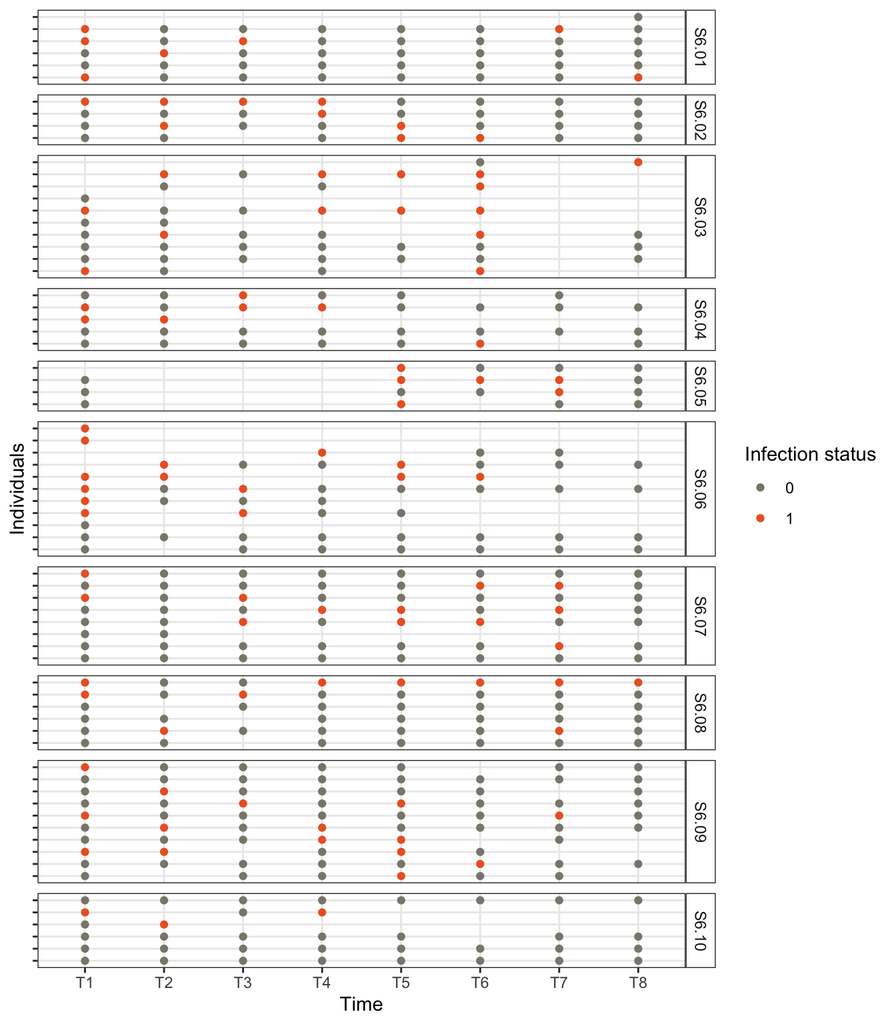

```r
p3_01a
```

### 3.1.2 By Date

**Figure 3.01b**

- Site S6: First 10 households shown as an example

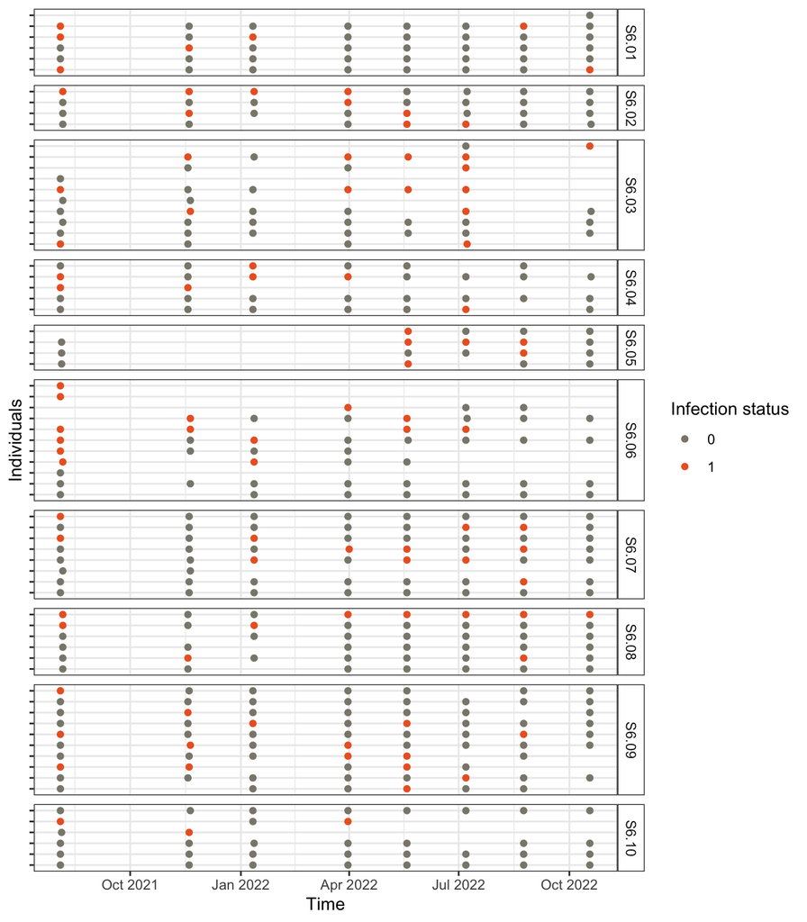

```r
p3_01b
```

```r
#creating plot objects for all
p_01_10 <- df5 %>%
  #Drop rows with no data
  filter(!is.na(rdt)) %>% filter(!is.na(sample.date)) %>%
  #Show X households at a time
  filter(hh_id %in% unique(df5$hh_id)[1:10]) %>%
  ggplot(aes(x = sample.date, y = unique_ind_id, color = as.factor(rdt))) +
  geom_point() +
  scale_colour_manual(values = p3_01a.cols) +
  facet_grid(rows = vars(hh_id), scales = "free_y", space = "free") +
  xlab("Time") + ylab("Individuals") +
  labs(color="Infection status") +
  theme_bw() +
  theme(strip.background = element_rect(fill = "white"),
        axis.text.y = element_blank())

p_11_20 <- df5 %>%
  #Drop rows with no data
  filter(!is.na(rdt)) %>% filter(!is.na(sample.date)) %>%
  #Show X households at a time
  filter(hh_id %in% unique(df5$hh_id)[11:20]) %>%
  ggplot(aes(x = sample.date, y = unique_ind_id, color = as.factor(rdt))) +
  geom_point() +
  scale_colour_manual(values = p3_01a.cols) +
  facet_grid(rows = vars(hh_id), scales = "free_y", space = "free") +
  xlab("Time") + ylab("Individuals") +
  labs(color="Infection status") +
  theme_bw() +
  theme(strip.background = element_rect(fill = "white"),
        axis.text.y = element_blank())

p_21_30 <- df5 %>%
  #Drop rows with no data
  filter(!is.na(rdt)) %>% filter(!is.na(sample.date)) %>%
  #Show X households at a time
  filter(hh_id %in% unique(df5$hh_id)[21:30]) %>%
  ggplot(aes(x = sample.date, y = unique_ind_id, color = as.factor(rdt))) +
  geom_point() +
  scale_colour_manual(values = p3_01a.cols) +
  facet_grid(rows = vars(hh_id), scales = "free_y", space = "free") +
  xlab("Time") + ylab("Individuals") +
  labs(color="Infection status") +
  theme_bw() +
  theme(strip.background = element_rect(fill = "white"),
        axis.text.y = element_blank())

p_31_40 <- df5 %>%
  #Drop rows with no data
  filter(!is.na(rdt)) %>% filter(!is.na(sample.date)) %>%
  #Show X households at a time
  filter(hh_id %in% unique(df5$hh_id)[31:40]) %>%
  ggplot(aes(x = sample.date, y = unique_ind_id, color = as.factor(rdt))) +
  geom_point() +
  scale_colour_manual(values = p3_01a.cols) +
  facet_grid(rows = vars(hh_id), scales = "free_y", space = "free") +
  xlab("Time") + ylab("Individuals") +
  labs(color="Infection status") +
  theme_bw() +
  theme(strip.background = element_rect(fill = "white"),
        axis.text.y = element_blank())

p_41_50 <- df5 %>%
  #Drop rows with no data
  filter(!is.na(rdt)) %>% filter(!is.na(sample.date)) %>%
  #Show X households at a time
  filter(hh_id %in% unique(df5$hh_id)[41:50]) %>%
  ggplot(aes(x = sample.date, y = unique_ind_id, color = as.factor(rdt))) +
  geom_point() +
  scale_colour_manual(values = p3_01a.cols) +
  facet_grid(rows = vars(hh_id), scales = "free_y", space = "free") +
  xlab("Time") + ylab("Individuals") +
  labs(color="Infection status") +
  theme_bw() +
  theme(strip.background = element_rect(fill = "white"),
        axis.text.y = element_blank())

p_51_58 <- df5 %>%
  #Drop rows with no data
  filter(!is.na(rdt)) %>% filter(!is.na(sample.date)) %>%
  #Show X households at a time
  filter(hh_id %in% unique(df5$hh_id)[51:58]) %>%
  ggplot(aes(x = sample.date, y = unique_ind_id, color = as.factor(rdt))) +
  geom_point() +
  scale_colour_manual(values = p3_01a.cols) +
  facet_grid(rows = vars(hh_id), scales = "free_y", space = "free") +
  xlab("Time") + ylab("Individuals") +
  labs(color="Infection status") +
  theme_bw() +
  theme(strip.background = element_rect(fill = "white"),
        axis.text.y = element_blank())
```

### 3.2.1 HHs 01_10

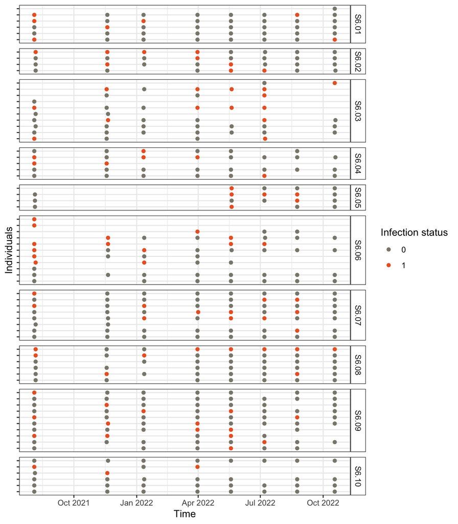

```r
p_01_10
```

### 3.2.2 HHs 11_20

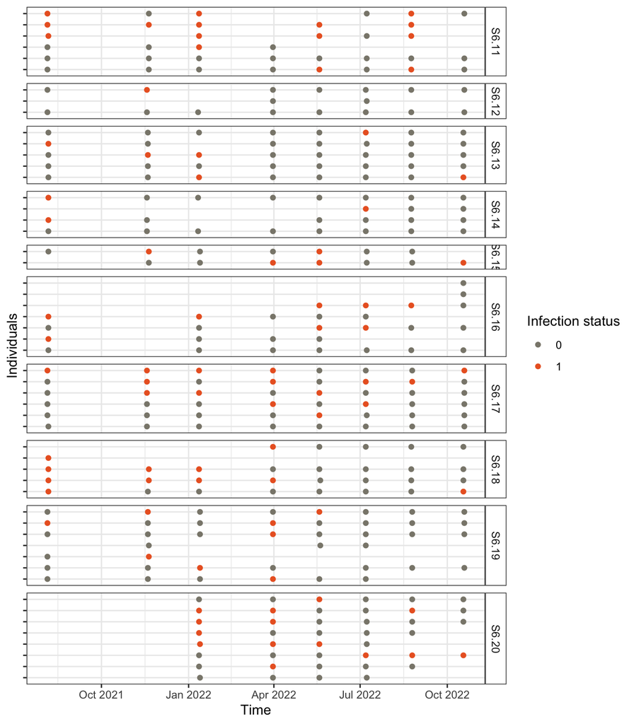

```r
p_11_20
```

### 3.2.3 HHs 21_30

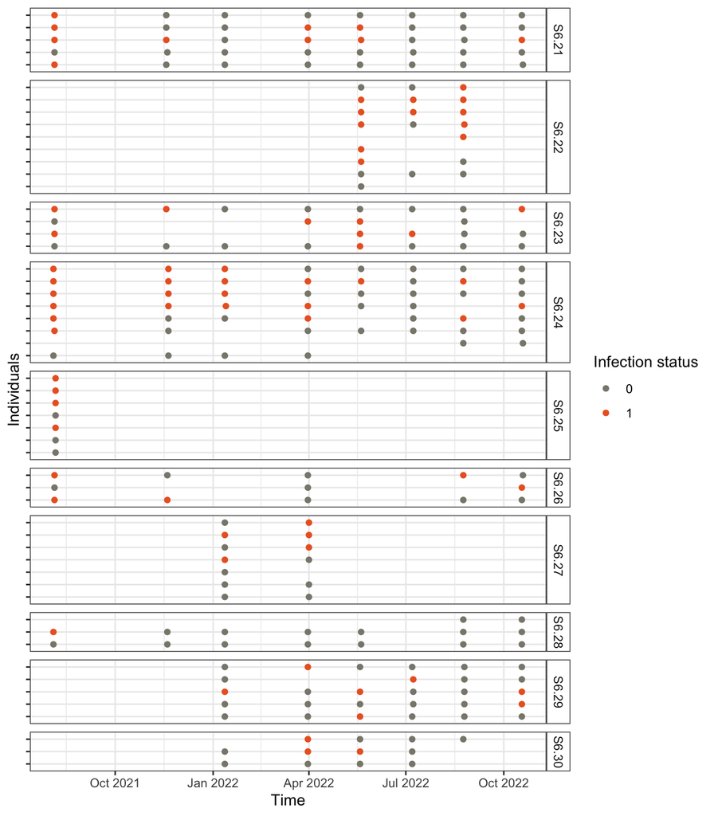

```r
p_21_30
```

### 3.2.4 HHs 31_40

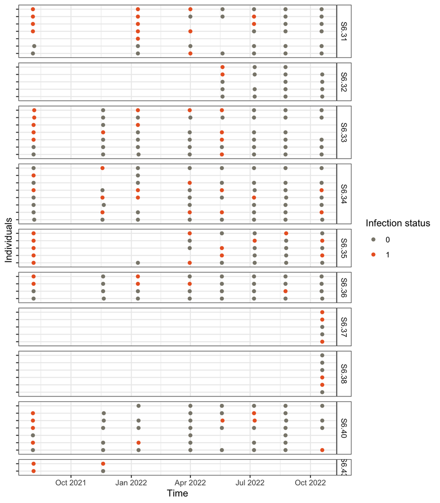

```r
p_31_40
```

### 3.2.5 HHs 41_50

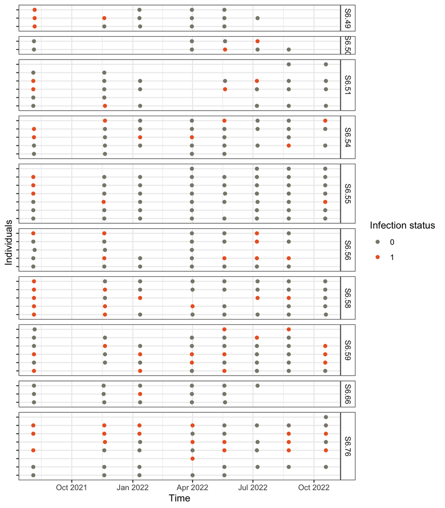

```r
p_41_50
```

### 3.2.6 HHs 51_58

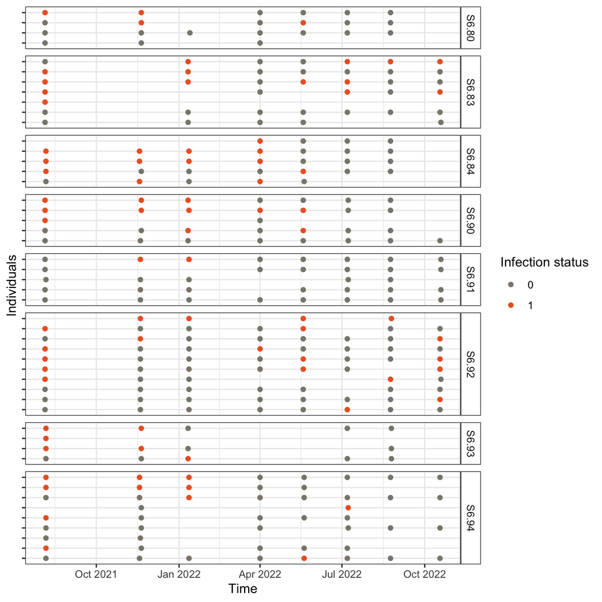

```r
p_51_58
```